# Meta-analysis physiological costs of estivation: Report 7 - OS

Pablo Capilla-Lasheras

2025-04-07

This [R Markdown](http://rmarkdown.rstudio.com) Notebook contains the initial meta-analysis for the project ‘physiological ’costs’ of hibernation and aestivation (this analysis is for estivation).

## Dataset and calculation of effect sizes

The dataset for this meta-analysis has been collected after a literature search by Pablo Burraco, Marko Prokic and Tamara Petrovic. It contains data on physiological effects of estivation in different systems. Here a quick snapshot of the first lines of the dataset:

|  | Reference | Year | Study_ID | Species | Family | Genus | Common.name | Type_of_animal | Thermoregulation | Class | Class_2 | Ver_Invert | Developmental_stage | Location | Experiment_venue | Biological.process | Tissue | Experimental_manipulation | Experimental.value | Biomarker_category | Biomarker_cat_2 | Biomarker_cat_3 | Specific_biomarker | Unit | Euthermia_N | Euthermia_M | Euthermia_SD | Euthermia_SE | Hib_N | … |
| --- | --- | --- | --- | --- | --- | --- | --- | --- | --- | --- | --- | --- | --- | --- | --- | --- | --- | --- | --- | --- | --- | --- | --- | --- | --- | --- | --- | --- | --- | --- |
| 1 | Giraud-Billoud et al 2013 | 2013 | study421 | Pomacea canaliculata | Ampullariidae | Pomacea | Apple snail | Snail | Ectothermic | Gastropoda | Arthopoda | Invertebrate | adults | Argentina | Laboratory | Estivation | kidney | none | NA | Non-enzymatic | Antioxidant | Non-enzymatic | uric acid | mmol/g | 6 | 5.853659e-02 | 0.08048780 | NA | 6 | … |
| 2 | Giraud-Billoud et al 2013 | 2013 | study421 | Pomacea canaliculata | Ampullariidae | Pomacea | Apple snail | Snail | Ectothermic | Gastropoda | Arthopoda | Invertebrate | adults | Argentina | Laboratory | Estivation | kidney | none | NA | Non-enzymatic | Antioxidant | Non-enzymatic | uric acid | mmol/g | 6 | 5.853659e-02 | 0.08048780 | NA | 6 | … |
| 3 | Samanta and Paital 2016 | 2016 | study112 | Duttaphrynus melanostictus | Bufonidae | Duttaphrynus | Asian Common Toad | Frog_toad | Ectothermic | Amphibia | Amphibia | Vertebrate | adults | India | Field | Estivation | Brain | none | male | Non-enzymatic | Antioxidant | Non-enzymatic | GSH | nmol/mg prot | 10 | 1.433198e+00 | 0.09716599 | NA | NA | … |
| 4 | Samanta and Paital 2016 | 2016 | study112 | Duttaphrynus melanostictus | Bufonidae | Duttaphrynus | Asian Common Toad | Frog_toad | Ectothermic | Amphibia | Amphibia | Vertebrate | adults | India | Field | Estivation | Gonad | none | male | Lipid_damage | Oxidative_damage | Oxidative_damage | TBARS | nmol/mg prot | 10 | 1.409091e+00 | 0.13636364 | NA | NA | … |
| 5 | Giraud-Billoud et al 2013 | 2013 | study421 | Pomacea canaliculata | Ampullariidae | Pomacea | Apple snail | Snail | Ectothermic | Gastropoda | Arthopoda | Invertebrate | adults | Argentina | Laboratory | Estivation | foot | none | NA | Non-enzymatic | Antioxidant | Non-enzymatic | uric acid | mmol/g | 6 | 2.146341e-01 | 0.28292683 | NA | 6 | … |
| 6 | Giraud-Billoud et al 2013 | 2013 | study421 | Pomacea canaliculata | Ampullariidae | Pomacea | Apple snail | Snail | Ectothermic | Gastropoda | Arthopoda | Invertebrate | adults | Argentina | Laboratory | Estivation | foot | none | NA | Non-enzymatic | Antioxidant | Non-enzymatic | uric acid | mmol/g | 6 | 2.146341e-01 | 0.28292683 | NA | 6 | … |
| 7 | Samanta and Paital 2016 | 2016 | study112 | Duttaphrynus melanostictus | Bufonidae | Duttaphrynus | Asian Common Toad | Frog_toad | Ectothermic | Amphibia | Amphibia | Vertebrate | adults | India | Field | Estivation | Gonad | none | male | Non-enzymatic | Antioxidant | Non-enzymatic | GSH | nmol/mg prot | 10 | 3.271255e+00 | 0.32388664 | NA | NA | … |
| 8 | Samanta and Paital 2016 | 2016 | study112 | Duttaphrynus melanostictus | Bufonidae | Duttaphrynus | Asian Common Toad | Frog_toad | Ectothermic | Amphibia | Amphibia | Vertebrate | adults | India | Field | Estivation | Brain | none | female | Non-enzymatic | Antioxidant | Non-enzymatic | GSH | nmol/mg prot | 10 | 1.821862e+00 | 0.38866397 | NA | NA | … |
| 9 | Samanta and Paital 2016 | 2016 | study112 | Duttaphrynus melanostictus | Bufonidae | Duttaphrynus | Asian Common Toad | Frog_toad | Ectothermic | Amphibia | Amphibia | Vertebrate | adults | India | Field | Hibernation and aestivation | Liver | none | male | Lipid_damage | Oxidative_damage | Oxidative_damage | TBARS | nmol/mg prot | 10 | 2.258824e+00 | 0.40000000 | NA | NA | … |
| 10 | Samanta and Paital 2016 | 2016 | study112 | Duttaphrynus melanostictus | Bufonidae | Duttaphrynus | Asian Common Toad | Frog_toad | Ectothermic | Amphibia | Amphibia | Vertebrate | adults | India | Field | Estivation | Liver | none | female | Lipid_damage | Oxidative_damage | Oxidative_damage | TBARS | nmol/mg prot | 10 | 2.729412e+00 | 0.42352941 | NA | NA | … |

[output cut: 506 more lines]

As a summary of the *initial dataset*:

- Number of studies: 21
- Number of species: 12

For this initial meta-analysis, I am going to include all oxidative stress (OS) markers and calculate the standarised mean difference (g) as the effect size of analysis comparing **estivation** *versus* **euthermia**. Positive SMD values indicate higher OS values in *estivation* while negative SMD indicate lower OS values in estivation. This is a summary of the effect size calculation based on the dataset above:

Summary of SMD effect size and number of observations included in the meta-analysis:

```
## Length  Class   Mode
##      0   NULL   NULL
```

- Number of observation with non-missing SMD: 477
- Number of studies in the dataset for analysis: 20
- Number of species in the dataset for analysis: 11

## Initial meta-analysis:

This initial model contains only the intercept and five random effects to account for variation between between classes, families, species, between studies and within studies beyond sampling variance.

```r
model_SMD <- rma.mv(yi = SMDH,
                    V = SMDH.sv,
                    mods = ~ 1,
                    random = list(~1|Study_ID,
                                  ~1|Class,
                                  ~1|Family,
                                  ~1|Species,
                                  ~1|obsID),
                    control=list(optimizer="BFGS"),
                    data=df_SMD,
                    method="REML")
```

```
##
## Multivariate Meta-Analysis Model (k = 477; method: REML)
##
##    logLik   Deviance        AIC        BIC       AICc
## -801.4047  1602.8095  1614.8095  1639.8020  1614.9886
##
## Variance Components:
##
##             estim    sqrt  nlvls  fixed    factor
## sigma^2.1  0.3430  0.5857     20     no  Study_ID
## sigma^2.2  0.0000  0.0010      3     no     Class
## sigma^2.3  0.0000  0.0011      9     no    Family
## sigma^2.4  0.0000  0.0026     11     no   Species
## sigma^2.5  0.6453  0.8033    477     no     obsID
##
## Test for Heterogeneity:
## Q(df = 476) = 1296.7111, p-val < .0001
##
## Model Results:
##
## estimate      se    zval    pval    ci.lb   ci.ub
##   0.2226  0.1479  1.5054  0.1322  -0.0672  0.5125
##
## ---
## Signif. codes:  0 '***' 0.001 '**' 0.01 '*' 0.05 '.' 0.1 ' ' 1
```

Proportion of variation left after accounting for sampling variance and proportion accounted by each random effect:

| Variable | i2_value_percentage |
| --- | --- |
| I2_Total | 66.914 |
| I2_Study_ID | 23.224 |
| I2_Class | 0.000 |
| I2_Family | 0.000 |
| I2_Species | 0.000 |
| I2_obsID | 43.689 |

### Plot of results of intercept-only model:

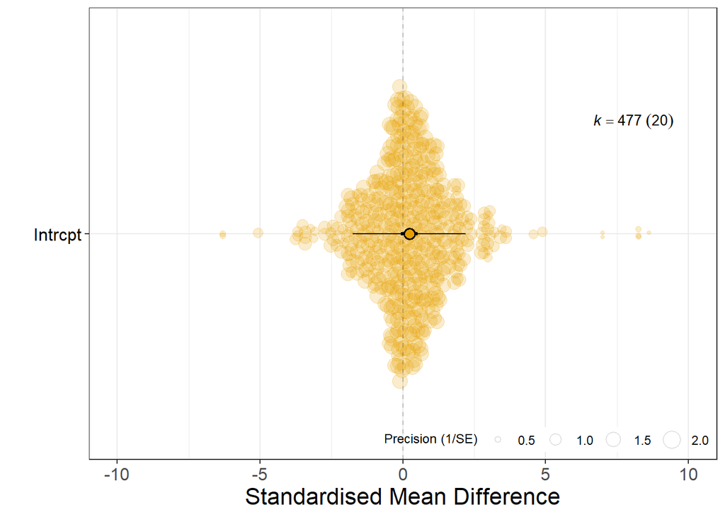

### Publication bias: small-study effects

```
##
## Multivariate Meta-Analysis Model (k = 477; method: REML)
##
##    logLik   Deviance        AIC        BIC       AICc
## -800.0367  1600.0735  1614.0735  1643.2167  1614.3133
##
## Variance Components:
##
##             estim    sqrt  nlvls  fixed    factor
## sigma^2.1  0.3479  0.5899     20     no  Study_ID
## sigma^2.2  0.0000  0.0000      3     no     Class
## sigma^2.3  0.0000  0.0001      9     no    Family
## sigma^2.4  0.0000  0.0002     11     no   Species
## sigma^2.5  0.6480  0.8050    477     no     obsID
##
## Test for Residual Heterogeneity:
## QE(df = 475) = 1295.4939, p-val < .0001
##
## Test of Moderators (coefficient 2):
## QM(df = 1) = 0.0013, p-val = 0.9709
##
## Model Results:
##
##                   estimate      se    zval    pval    ci.lb   ci.ub
## intrcpt             0.2013  0.6119  0.3290  0.7421  -0.9980  1.4007
## sqrt(inv_eff_ss)    0.0378  1.0362  0.0365  0.9709  -1.9931  2.0688
##
## ---
## Signif. codes:  0 '***' 0.001 '**' 0.01 '*' 0.05 '.' 0.1 ' ' 1
```

```
##    R2_marginal R2_conditional
##   6.901793e-06   3.493441e-01
```

### Publication bias: time-lag effects

```
##
## Multivariate Meta-Analysis Model (k = 477; method: REML)
##
##    logLik   Deviance        AIC        BIC       AICc
## -797.9632  1595.9264  1609.9264  1639.0696  1610.1662
##
## Variance Components:
##
##             estim    sqrt  nlvls  fixed    factor
## sigma^2.1  0.2843  0.5332     20     no  Study_ID
## sigma^2.2  0.0000  0.0001      3     no     Class
## sigma^2.3  0.0000  0.0000      9     no    Family
## sigma^2.4  0.0000  0.0001     11     no   Species
## sigma^2.5  0.6475  0.8047    477     no     obsID
##
## Test for Residual Heterogeneity:
## QE(df = 475) = 1258.5945, p-val < .0001
##
## Test of Moderators (coefficient 2):
## QM(df = 1) = 2.9836, p-val = 0.0841
##
## Model Results:
##
##              estimate      se    zval    pval    ci.lb   ci.ub
## intrcpt        0.1959  0.1377  1.4221  0.1550  -0.0741  0.4658
## scale(Year)    0.2399  0.1389  1.7273  0.0841  -0.0323  0.5122  .
##
## ---
## Signif. codes:  0 '***' 0.001 '**' 0.01 '*' 0.05 '.' 0.1 ' ' 1
```

```
##    R2_marginal R2_conditional
##     0.05818074     0.34554743
```

## Meta-analysis with all organisms but including different OS markers:

Number of observations for each type:

```
##
##      Antioxidant Oxidative_damage       Regulatory              ROS
##              375               89                8                5
```

```
##
## Multivariate Meta-Analysis Model (k = 477; method: REML)
##
##    logLik   Deviance        AIC        BIC       AICc
## -795.2761  1590.5522  1608.5522  1645.9841  1608.9410
##
## Variance Components:
##
##             estim    sqrt  nlvls  fixed    factor
## sigma^2.1  0.3321  0.5763     20     no  Study_ID
## sigma^2.2  0.0000  0.0000      3     no     Class
## sigma^2.3  0.0000  0.0000      9     no    Family
## sigma^2.4  0.0000  0.0002     11     no   Species
## sigma^2.5  0.6524  0.8077    477     no     obsID
##
## Test for Residual Heterogeneity:
## QE(df = 473) = 1283.0610, p-val < .0001
##
## Test of Moderators (coefficients 1:4):
## QM(df = 4) = 7.7626, p-val = 0.1007
##
## Model Results:
##
##                                  estimate      se    zval    pval    ci.lb
## Biomarker_cat_2Antioxidant         0.1642  0.1485  1.1054  0.2690  -0.1269
## Biomarker_cat_2Oxidative_damage    0.4358  0.1831  2.3803  0.0173   0.0769
## Biomarker_cat_2Regulatory          0.0610  0.5370  0.1135  0.9096  -0.9916
## Biomarker_cat_2ROS                 0.7706  0.5288  1.4572  0.1451  -0.2659
##                                   ci.ub
## Biomarker_cat_2Antioxidant       0.4552
## Biomarker_cat_2Oxidative_damage  0.7946  *
## Biomarker_cat_2Regulatory        1.1136
## Biomarker_cat_2ROS               1.8071
##
## ---
## Signif. codes:  0 '***' 0.001 '**' 0.01 '*' 0.05 '.' 0.1 ' ' 1
```

```
##
## Multivariate Meta-Analysis Model (k = 477; method: REML)
##
##    logLik   Deviance        AIC        BIC       AICc
## -795.2761  1590.5522  1608.5522  1645.9841  1608.9410
##
## Variance Components:
##
##             estim    sqrt  nlvls  fixed    factor
## sigma^2.1  0.3321  0.5763     20     no  Study_ID
## sigma^2.2  0.0000  0.0000      3     no     Class
## sigma^2.3  0.0000  0.0000      9     no    Family
## sigma^2.4  0.0000  0.0002     11     no   Species
## sigma^2.5  0.6524  0.8077    477     no     obsID
##
## Test for Residual Heterogeneity:
## QE(df = 473) = 1283.0610, p-val < .0001
##
## Test of Moderators (coefficients 1:4):
## QM(df = 4) = 7.7626, p-val = 0.1007
##
## Model Results:
##
##                                  estimate      se    zval    pval    ci.lb
## Biomarker_cat_2Antioxidant         0.1642  0.1485  1.1054  0.2690  -0.1269
## Biomarker_cat_2Oxidative_damage    0.4358  0.1831  2.3803  0.0173   0.0769
## Biomarker_cat_2Regulatory          0.0610  0.5370  0.1135  0.9096  -0.9916
## Biomarker_cat_2ROS                 0.7706  0.5288  1.4572  0.1451  -0.2659
##                                   ci.ub
## Biomarker_cat_2Antioxidant       0.4552
## Biomarker_cat_2Oxidative_damage  0.7946  *
## Biomarker_cat_2Regulatory        1.1136
## Biomarker_cat_2ROS               1.8071
##
## ---
## Signif. codes:  0 '***' 0.001 '**' 0.01 '*' 0.05 '.' 0.1 ' ' 1
```

### Plot of results of biomarker meta-regression:

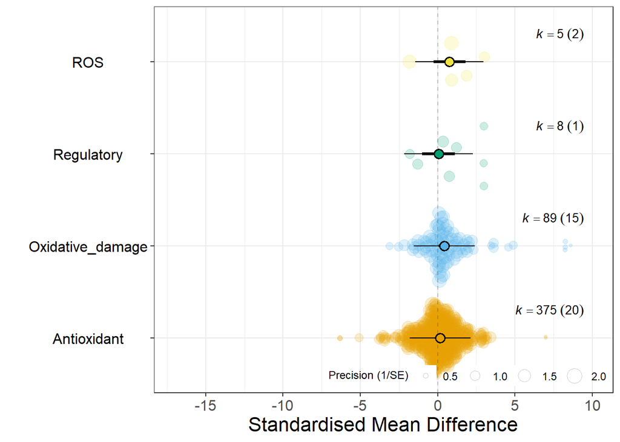

## Meta-analysis including thermoregulation type as a moderator:

Analysis can’t be done because the dataset only includes ectothermic organisms (i.e., results above refer to ectotherms).